# Part II - Communcating Loan Data Findings from Prosper

## by Israel Daniel

## Investigation Overview

> For the loan terms, loans of 36 months had a very high frequency of 69% compared to other terms, with loan terms of 60 months following with a much lower frequency of 29% and 12 months falling behind with a small frequency of just 2%.

> While exploring, it was discovered that average earners to tend to fall under the risk scores from 1.0 - 8.0 of which they led in those scores among other earners, the richer borrowers usually had the best risk scores due to their earning potential.

> It was also discovered that most of the original loan amounts had low interest rates, with some of them below 15,000 having very high rates.

## Dataset Overview

> This data set contains 113,937 loans with 81 variables on each loan, including loan amount, borrower rate (or interest rate), current loan status, borrower income, and many others..

### What is the percentage frequency of the loan terms?

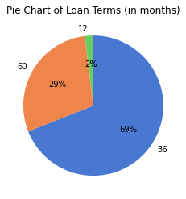

From the above chart, 36 months is the most frequent term preferred among borrowers with a leading percentage of 69%, with 60 months following next with a much lower percentage frequency of 29%. 12 months comes up as the option with the lowest frequency of just 2% among others.

## Relationship between the Income Range and the Loan's Risk Score?

> The chart below will help us depict the relationship between these two variables.

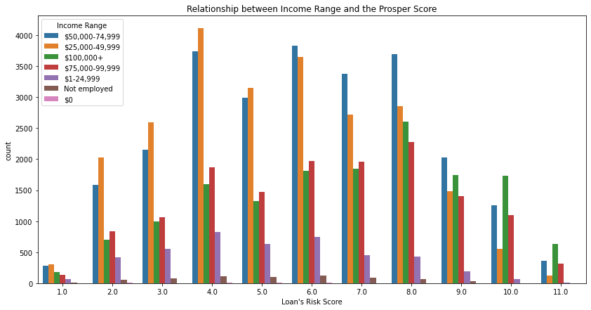

## What affects the borrower's interest?

**The loan terms and employment status tend to affect the borrower's interest and will be seen in the next slide.**

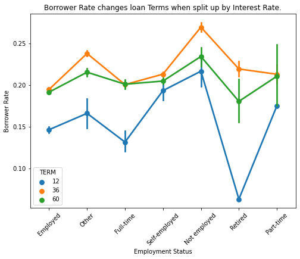

## What affects the borrower’s APR?

**Terms and Employment Status will be compared with the Borrower's APR.**

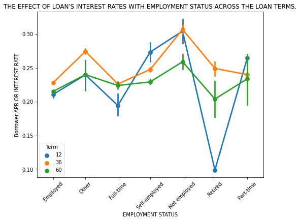

From the visualization above, those among the not-employed tend to have the highest interest rates, while those among the retired tend to have the smallest rates among the three terms (with the exception of the 36 months term, where full-time carries the shortest rates). The interest rates for retired borrowers exhibits the highest variance among the term, while employed borrowers exhibits the lowest variance.

## Multivariate Relationship between Borrower Rate, Monthly Loan Payment and the Original Loan Amount.

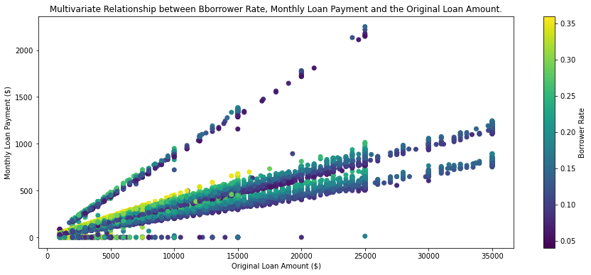

Most of the loans exhibits low interest rates. Although, some of the original loan amounts below 15,000 tend to have very high rates which I think is as a result or high risk scores.

### Multivariate Relationship between Prosper Score, Monthly Loan Payment and the Original Loan Amount?

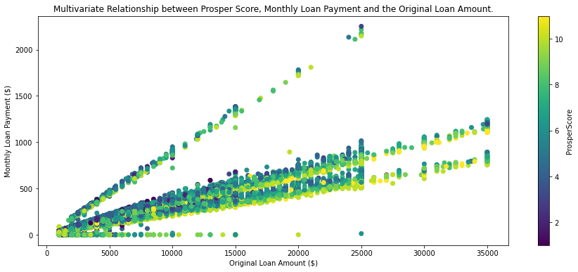

From the chart above, there seem to be a steady rise between monthly loan payment and original loan amount, though not distinct as they are some values not following the common trend. The risk score does not possess a common trend but there seem to be most of the lower scores among the lower values with most of the higher score among the higher values.